# Get started with modeltools

## Installation

**This package is not on CRAN!**

Delphi’s `modeltools` package can be installed from our [**GitHub page**](https://github.com/cmu-delphi/covidcast/tree/main/R-packages/modeltools) with the command below. The CRAN `modeltools` package is entirely unrelated to this one.

```r
devtools::install_github(repo = "cmu-delphi/covidcast", subdir = "R-packages/modeltools",
                         ref = "collin-develop", build_vignettes = TRUE)
```

## Downloading COVIDcast signals

In these vignettes, we’ll illustrate the suite of tools provided by the `modeltools` package for analyzing, manipulating, and forecasting the COVID-19 signals available in Delphi’s [**COVIDcast Epidata API**](https://cmu-delphi.github.io/delphi-epidata/api/covidcast_signals.html). The examples we provide here will center around the progression of COVID-19 case rates (i.e. the number of new COVID-19 cases reported per day, per 100,000 population), as reported by [**USAFacts**](https://usafacts.org/), over the course of the pandemic.

The code chunk below utilizes Delphi’s COVIDcast API `R` client to fetch the reported case rates for four U.S. states — CA, FL, NY, and PA — starting on March 1, 2020. See the `covidcast` [**Getting started guide**](https://cmu-delphi.github.io/covidcast/covidcastR/articles/covidcast.html) for more examples on how to use the Delphi API’s `R` client.

```r
library(covidcast)
library(dplyr)

source <- "usa-facts"
start_day <- "2020-03-01"
end_day <- Sys.Date() - 5
geo_values <- c("ca","fl","ny","pa")

case_rates <- covidcast_signals(data_source = source,
                               signal = c("confirmed_incidence_prop",
                                          "confirmed_7dav_incidence_prop"),
                               start_day = start_day,
                               end_day = end_day,
                               geo_type = "state",
                               geo_values = geo_values) %>%
  aggregate_signals(format = "wide") %>%
  setNames(gsub(paste0("value\\+0:", source, "_"), "", names(.))) %>%
  arrange(geo_value, time_value)
```

As with other signals stored in Delphi’s API, the API also computes and stores a smoothed version of the USAFacts case rates signal — a 7-day trailing average of the (raw) daily case rates reported by USAFacts. The code chunk above pulls both the raw and smoothed signals from the API and aggregates them into the “wide format” data frame displayed below.

| geo_value | time_value | confirmed_incidence_prop | confirmed_7dav_incidence_prop |
| --- | --- | --- | --- |
| ca | 2020-03-01 | 0 | 0.00361551773123833 |
| ca | 2020-03-02 | 0.0202468992949346 | 0.00614638014310516 |
| ca | 2020-03-03 | 0.0101234496474673 | 0.00759258723560049 |
| ca | 2020-03-04 | 0.0354320737661356 | 0.0119312085130865 |
| ca | 2020-03-05 | 0.0354320737661356 | 0.0166313815636963 |
| ca | 2020-03-06 | 0.0430246610017361 | 0.0220546581605538 |
| ca | 2020-03-07 | 0.1012345 | 0.0350705 |
| ca | 2020-03-08 | 0.030370348942402 | 0.0394091 |
| ca | 2020-03-09 | 0.15944433194761 | 0.0592945 |
| ca | 2020-03-10 | 0.0683332851204044 | 0.0676102 |

[output cut: 2230 more lines]

[output not shown]

[output cut: 2230 more lines]

State

**Show Source Code**

```r
library(reactable)
library(crosstalk)

case_rates_data <- SharedData$new(case_rates, group = "geo_value")
col3.header <- JS("function(colInfo) {return colInfo.column.name + '<div style=\"color: #999\">Cases per 100,000</div>'}")
col4.header <- JS("function(colInfo) {return colInfo.column.name + '<div style=\"color: #999\">Cases per 100,000 (smoothed)</div>'}")
col2.def <- colDef(html = T, format = colFormat(date = T), sortable = T,
                   align = "right", maxWidth = 100)
col3.def <- colDef(minWidth = 170, html = T, format = colFormat(digits = 3),
                   sortable = T, align = "center", header = col3.header)
col4.def <- colDef(minWidth = 200, html = T, format = colFormat(digits = 3),
                   sortable = T, align = "center", header = col4.header )

columns <- list(geo_value = colDef(html = T, align = "left", maxWidth = 90),
                time_value = col2.def, confirmed_incidence_prop = col3.def,
                confirmed_7dav_incidence_prop = col4.def)

case_rates_tbl <- reactable(case_rates_data, sortable = F, showSortable = T,
                            striped = T, defaultPageSize = 10, paginationType = "jump",
                            columns = columns)

bscols(case_rates_tbl, list(filter_select("geo_value", "State", case_rates_data, ~toupper(geo_value), multiple = F)),
       widths = c(10,2), device = "lg")
```

The reported USAFacts case rates, with 7-day trailing averages superposed, are plotted below for each of the four states.

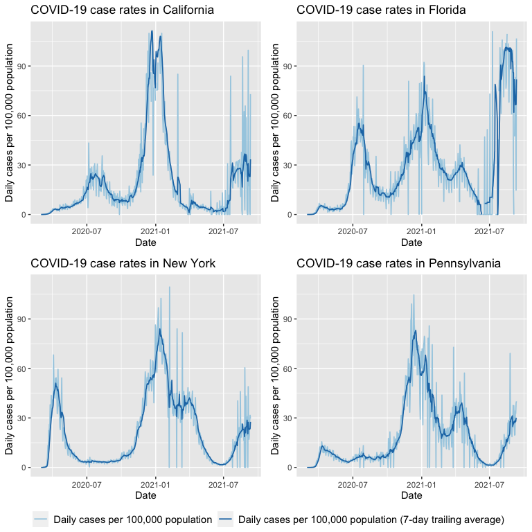

**Show Source Code**

```r
library(tidyr)
library(ggplot2)
library(ggpubr)

case_rates <- case_rates %>% pivot_longer(3:4)
max.y <- case_rates %>%
  filter(name == "confirmed_7dav_incidence_prop") %>%
  pull(value) %>%
  max

CA <- ggplot(case_rates %>% filter(geo_value == "ca"), aes(x = time_value)) +
  scale_color_manual(labels = c("Daily cases per 100,000 population",
                                "Daily cases per 100,000 population (7-day trailing average)"),
                     values = c("#A6CEE3", "#1F78B4")) +
  ylim(0, max.y) +
  geom_line(aes(y = value, col = rev(name)), size = 0.6) +
  theme(legend.position = "none", legend.title = element_blank(), legend.text = element_text(size = 11)) +
  labs(x = "Date", y = "Daily cases per 100,000 population", title = "COVID-19 case rates in California")

FL <- ggplot(case_rates %>% filter(geo_value == "fl"), aes(x = time_value)) +
  scale_colour_brewer(type = "qual", palette = 3) +
  ylim(0, max.y) +
  geom_line(aes(y = value, col = rev(name)), size = 0.6) +
  labs(x = "Date", y = "Daily cases per 100,000 population", title = "COVID-19 case rates in Florida")

NY <- ggplot(case_rates %>% filter(geo_value == "ny"), aes(x = time_value)) +
  scale_colour_brewer(type = "qual", palette = 3) +
  ylim(0, max.y) +
  geom_line(aes(y = value, col = rev(name)), size = 0.6) +
  labs(x = "Date", y = "Daily cases per 100,000 population", title = "COVID-19 case rates in New York")

TX <- ggplot(case_rates %>% filter(geo_value == "pa"), aes(x = time_value)) +
  scale_colour_brewer(type = "qual", palette = 3) +
  ylim(0, max.y) +
  geom_line(aes(y = value, col = rev(name)), size = 0.6) +
  labs(x = "Date", y = "Daily cases per 100,000 population", title = "COVID-19 case rates in Pennsylvania")

ggarrange(CA, FL, NY, TX, nrow = 2, ncol = 2, common.legend = T, legend = "bottom", align = "hv")
```